# Final Project on Student Depression

Data Pandas

2025-04-24

*Loading the Dataset*

```r
student_depression_dataset <- read.csv("student_depression_dataset.csv")
```

*Data Preview*

Before cleaning the data, let’s explore the import to get a sense of what we are starting with.

```r
head(student_depression_dataset, n=5)
```

```
##   id Gender Age          City Profession Academic.Pressure Work.Pressure CGPA
## 1  2   Male  33 Visakhapatnam    Student                 5             0 8.97
## 2  8 Female  24     Bangalore    Student                 2             0 5.90
## 3 26   Male  31      Srinagar    Student                 3             0 7.03
## 4 30 Female  28      Varanasi    Student                 3             0 5.59
## 5 32 Female  25        Jaipur    Student                 4             0 8.13
##   Study.Satisfaction Job.Satisfaction      Sleep.Duration Dietary.Habits
## 1                  2                0         '5-6 hours'        Healthy
## 2                  5                0         '5-6 hours'       Moderate
## 3                  5                0 'Less than 5 hours'        Healthy
## 4                  2                0         '7-8 hours'       Moderate
## 5                  3                0         '5-6 hours'       Moderate
##    Degree Have.you.ever.had.suicidal.thoughts.. Work.Study.Hours
## 1 B.Pharm                                   Yes                3
## 2     BSc                                    No                3
## 3      BA                                    No                9
## 4     BCA                                   Yes                4
## 5  M.Tech                                   Yes                1
##   Financial.Stress Family.History.of.Mental.Illness Depression
## 1              1.0                               No          1
## 2              2.0                              Yes          0
## 3              1.0                              Yes          0
## 4              5.0                              Yes          1
## 5              1.0                               No          0
```

```r
tail(student_depression_dataset, n=3)
```

```
##           id Gender Age      City Profession Academic.Pressure Work.Pressure
## 27899 140689   Male  31 Faridabad    Student                 3             0
## 27900 140690 Female  18  Ludhiana    Student                 5             0
## 27901 140699   Male  27     Patna    Student                 4             0
##       CGPA Study.Satisfaction Job.Satisfaction      Sleep.Duration
## 27899 6.61                  4                0         '5-6 hours'
## 27900 6.88                  2                0 'Less than 5 hours'
## 27901 9.24                  1                0 'Less than 5 hours'
##       Dietary.Habits     Degree Have.you.ever.had.suicidal.thoughts..
## 27899      Unhealthy         MD                                    No
## 27900        Healthy 'Class 12'                                   Yes
## 27901        Healthy        BCA                                   Yes
##       Work.Study.Hours Financial.Stress Family.History.of.Mental.Illness
## 27899               12              2.0                               No
## 27900               10              5.0                               No
## 27901                2              3.0                              Yes
##       Depression
## 27899          0
## 27900          1
## 27901          1
```

```r
str(student_depression_dataset)
```

```
## 'data.frame':    27901 obs. of  18 variables:
##  $ id                                   : int  2 8 26 30 32 33 52 56 59 62 ...
##  $ Gender                               : chr  "Male" "Female" "Male" "Female" ...
##  $ Age                                  : num  33 24 31 28 25 29 30 30 28 31 ...
##  $ City                                 : chr  "Visakhapatnam" "Bangalore" "Srinagar" "Varanasi" ...
##  $ Profession                           : chr  "Student" "Student" "Student" "Student" ...
##  $ Academic.Pressure                    : num  5 2 3 3 4 2 3 2 3 2 ...
##  $ Work.Pressure                        : num  0 0 0 0 0 0 0 0 0 0 ...
##  $ CGPA                                 : num  8.97 5.9 7.03 5.59 8.13 5.7 9.54 8.04 9.79 8.38 ...
##  $ Study.Satisfaction                   : num  2 5 5 2 3 3 4 4 1 3 ...
##  $ Job.Satisfaction                     : num  0 0 0 0 0 0 0 0 0 0 ...
##  $ Sleep.Duration                       : chr  "'5-6 hours'" "'5-6 hours'" "'Less than 5 hours'" "'7-8 hours'" ...
##  $ Dietary.Habits                       : chr  "Healthy" "Moderate" "Healthy" "Moderate" ...
##  $ Degree                               : chr  "B.Pharm" "BSc" "BA" "BCA" ...
##  $ Have.you.ever.had.suicidal.thoughts..: chr  "Yes" "No" "No" "Yes" ...
##  $ Work.Study.Hours                     : num  3 3 9 4 1 4 1 0 12 2 ...
##  $ Financial.Stress                     : chr  "1.0" "2.0" "1.0" "5.0" ...
##  $ Family.History.of.Mental.Illness     : chr  "No" "Yes" "Yes" "Yes" ...
##  $ Depression                           : int  1 0 0 1 0 0 0 0 1 1 ...
```

```r
summary(student_depression_dataset)
```

```
##        id            Gender               Age            City
##  Min.   :     2   Length:27901       Min.   :18.00   Length:27901
##  1st Qu.: 35039   Class :character   1st Qu.:21.00   Class :character
##  Median : 70684   Mode  :character   Median :25.00   Mode  :character
##  Mean   : 70442                      Mean   :25.82
##  3rd Qu.:105818                      3rd Qu.:30.00
##  Max.   :140699                      Max.   :59.00
##   Profession        Academic.Pressure Work.Pressure          CGPA
##  Length:27901       Min.   :0.000     Min.   :0.00000   Min.   : 0.000
##  Class :character   1st Qu.:2.000     1st Qu.:0.00000   1st Qu.: 6.290
##  Mode  :character   Median :3.000     Median :0.00000   Median : 7.770
##                     Mean   :3.141     Mean   :0.00043   Mean   : 7.656
##                     3rd Qu.:4.000     3rd Qu.:0.00000   3rd Qu.: 8.920
##                     Max.   :5.000     Max.   :5.00000   Max.   :10.000
##  Study.Satisfaction Job.Satisfaction   Sleep.Duration     Dietary.Habits
##  Min.   :0.000      Min.   :0.000000   Length:27901       Length:27901
##  1st Qu.:2.000      1st Qu.:0.000000   Class :character   Class :character
##  Median :3.000      Median :0.000000   Mode  :character   Mode  :character
##  Mean   :2.944      Mean   :0.000681
##  3rd Qu.:4.000      3rd Qu.:0.000000
##  Max.   :5.000      Max.   :4.000000
##     Degree          Have.you.ever.had.suicidal.thoughts.. Work.Study.Hours
##  Length:27901       Length:27901                          Min.   : 0.000
##  Class :character   Class :character                      1st Qu.: 4.000
##  Mode  :character   Mode  :character                      Median : 8.000
##                                                           Mean   : 7.157
##                                                           3rd Qu.:10.000
##                                                           Max.   :12.000
##  Financial.Stress   Family.History.of.Mental.Illness   Depression
##  Length:27901       Length:27901                     Min.   :0.0000
##  Class :character   Class :character                 1st Qu.:0.0000
##  Mode  :character   Mode  :character                 Median :1.0000
##                                                      Mean   :0.5855
##                                                      3rd Qu.:1.0000
##                                                      Max.   :1.0000
```

ID Gender Age City Profession Academic Pressure Work Pressure CGPA Study Satisfaction Job Satisfaction Sleep Duration Dietary Habits Degree Suicidal Thoughts Work/Study Hours Financial Stress Family History of Mental Illness Depression

*Data Cleaning*

To make our analysis easier, we can remove some of the unnecessary columns like Id, Profession, City. We will also remove the Work presuure and Job satisfaction since our main goal is to Identify the students who are at risk

```r
student_depression_dataset$id <- NULL
student_depression_dataset$Profession <- NULL
student_depression_dataset$City <- NULL
student_depression_dataset$Work.Pressure <- NULL
student_depression_dataset$Job.Satisfaction <- NULL
student_depression_dataset$Study.Hours <- student_depression_dataset$Work.Study.Hours
student_depression_dataset$Work.Study.Hours<- NULL
```

Check for duplicates and missing values

```r
duplicates_count <- sum(duplicated(student_depression_dataset))
duplicates_count
```

```
## [1] 0
```

```r
student_depression_dataset <- student_depression_dataset[!duplicated(student_depression_dataset), ]

cat("Number of duplicates removed:", duplicates_count, "\n")
```

```
## Number of duplicates removed: 0
```

```r
cat("Rows remaining after removing duplicates:", nrow(student_depression_dataset), "\n")
```

```
## Rows remaining after removing duplicates: 27901
```

```r
str(student_depression_dataset)
```

```
## 'data.frame':    27901 obs. of  13 variables:
##  $ Gender                               : chr  "Male" "Female" "Male" "Female" ...
##  $ Age                                  : num  33 24 31 28 25 29 30 30 28 31 ...
##  $ Academic.Pressure                    : num  5 2 3 3 4 2 3 2 3 2 ...
##  $ CGPA                                 : num  8.97 5.9 7.03 5.59 8.13 5.7 9.54 8.04 9.79 8.38 ...
##  $ Study.Satisfaction                   : num  2 5 5 2 3 3 4 4 1 3 ...
##  $ Sleep.Duration                       : chr  "'5-6 hours'" "'5-6 hours'" "'Less than 5 hours'" "'7-8 hours'" ...
##  $ Dietary.Habits                       : chr  "Healthy" "Moderate" "Healthy" "Moderate" ...
##  $ Degree                               : chr  "B.Pharm" "BSc" "BA" "BCA" ...
##  $ Have.you.ever.had.suicidal.thoughts..: chr  "Yes" "No" "No" "Yes" ...
##  $ Financial.Stress                     : chr  "1.0" "2.0" "1.0" "5.0" ...
##  $ Family.History.of.Mental.Illness     : chr  "No" "Yes" "Yes" "Yes" ...
##  $ Depression                           : int  1 0 0 1 0 0 0 0 1 1 ...
##  $ Study.Hours                          : num  3 3 9 4 1 4 1 0 12 2 ...
```

```r
missing_values <- colSums(is.na(student_depression_dataset))
missing_values
```

```
##                                Gender                                   Age
##                                     0                                     0
##                     Academic.Pressure                                  CGPA
##                                     0                                     0
##                    Study.Satisfaction                        Sleep.Duration
##                                     0                                     0
##                        Dietary.Habits                                Degree
##                                     0                                     0
## Have.you.ever.had.suicidal.thoughts..                      Financial.Stress
##                                     0                                     0
##      Family.History.of.Mental.Illness                            Depression
##                                     0                                     0
##                           Study.Hours
##                                     0
```

We also need to convert some variables into the proper type.

Let’s see the unique values in every column so that we can change their type accordingly

```r
for (col in names(student_depression_dataset)) {
  cat("\n\nColumn:", col, "\n")
  print(unique(student_depression_dataset[[col]]))
}
```

```
##
##
## Column: Gender
## [1] "Male"   "Female"
##
##
## Column: Age
##  [1] 33 24 31 28 25 29 30 27 19 20 23 18 21 22 34 32 26 39 35 42 36 58 49 38 51
## [26] 44 43 46 59 54 48 56 37 41
##
##
## Column: Academic.Pressure
## [1] 5 2 3 4 1 0
##
##
## Column: CGPA
##   [1]  8.9700  5.9000  7.0300  5.5900  8.1300  5.7000  9.5400  8.0400  9.7900
##  [10]  8.3800  6.1000  7.0400  8.5200  5.6400  8.5800  6.5100  7.2500  7.8300
##  [19]  9.9300  8.7400  6.7300  5.5700  8.5900  7.1000  6.0800  5.7400  9.8600
##  [28]  6.7000  6.2100  5.8700  6.3700  9.7200  5.8800  9.5600  6.9900  5.2400
##  [37]  9.2100  7.8500  6.9500  5.8600  7.9200  9.6600  8.9400  9.7100  7.8700
##  [46]  5.6000  7.9000  5.4600  6.7900  8.7000  7.3800  8.5000  7.0900  9.8200
##  [55]  8.8900  7.9400  9.1100  6.7500  7.5300  9.4900  9.0100  7.6400  5.2700
##  [64]  6.0000  9.4400  5.7500  7.5100  9.0500  6.3800  8.9500  9.8800  5.3200
##  [73]  6.2700  7.7000  8.1000  9.5900  8.9600  5.5100  7.4300  8.7900  9.9500
##  [82]  5.3700  6.8600  8.3200  9.7400  5.6600  7.4800  8.2300  8.8100  6.0300
##  [91]  5.5600  5.6800  5.1400  7.6100  6.1700  8.1700  9.8700  8.7500  6.1600
## [100]  9.5000  7.9900  5.6700  8.9200  6.1900  5.7600  6.2500  5.1100  5.5800
## [109]  5.6500  9.8900  8.0300  6.6100  9.4100  8.6400  7.2100  8.2800  6.0400
## [118]  9.1300  8.0800  9.9600  5.1200  8.3500  7.0700  9.6000  9.2400  8.5400
## [127]  8.7800  8.9300  8.9100  9.0400  6.8300  5.8500  7.7400  6.4100  8.9000
## [136]  7.7500  7.8800  5.4200  7.5200  7.6800  8.4000  9.3900  6.8400  5.9900
## [145]  8.6200  8.5300  7.4700  6.7800  6.4200  9.9200  8.3900  5.8900  7.2200
## [154]  6.8100  9.0200  9.9700  9.6300  9.6700  5.4100  7.2700  6.0500  6.8500
## [163]  9.3300  5.8100  6.5300  5.9800  6.0200  6.7400  5.2600  7.7200  7.3900
## [172]  8.4300  9.3400  5.4400  5.8200  5.7200  8.1900  8.4400  8.9800  9.3700
## [181]  5.8000  7.2800  7.6000  7.9100  9.1700  7.4600  9.4300  9.9100  9.3600
## [190]  5.1600  7.0800  9.2600  8.8300 10.0000  7.8000  9.4600  6.6300  7.2400
## [199]  6.4700  7.7700  5.0600  7.1700  8.2400  6.8800  9.0300  5.0800  5.4500
## [208]  8.4600  9.1900  6.3600  8.7300  7.1100  9.1200  9.4000  8.1100  9.9800
```

[output cut: 40 more lines]

```
##
## Column: Financial.Stress
## [1] "1.0" "2.0" "5.0" "3.0" "4.0" "?"
##
##
## Column: Family.History.of.Mental.Illness
## [1] "No"  "Yes"
##
##
## Column: Depression
## [1] 1 0
##
##
## Column: Study.Hours
##  [1]  3  9  4  1  0 12  2 11 10  6  8  5  7
```

First’ We will convert the Degree to years of education and make the Sleep Duration a numerical variable.

```r
student_depression_dataset$Degree <- gsub("[‘’'“”\"]", "", student_depression_dataset$Degree)
student_depression_dataset$Sleep.Duration <- gsub("[‘’'“”\"]", "", student_depression_dataset$Sleep.Duration)

student_depression_dataset$Education.Years <- recode(student_depression_dataset$Degree,
  "Class 12" = 12,
  "BA" = 16, "BSc" = 16, "B.Com" = 16, "BBA" = 16, "BCA" = 16, "B.Ed" = 16,
  "B.Tech" = 16, "BE" = 16, "BHM" = 16, "B.Arch" = 16, "B.Pharm" = 16, "MBBS" = 16, "LLB" = 16,
  "MA" = 18, "MSc" = 18, "M.Com" = 18, "M.Ed" = 18, "M.Tech" = 18, "MBA" = 18,
  "MCA" = 18, "ME" = 18, "M.Pharm" = 18, "MHM" = 18, "LLM" = 18, "MD" = 18,
  "PhD" = 21,
  "Others" = 16,
  .default = 16

)

student_depression_dataset$Sleep.Hours <- recode(student_depression_dataset$Sleep.Duration,
  "Less than 5 hours" = 4,
  "5-6 hours" = 5.5,
  "7-8 hours" = 7.5,
  "More than 8 hours" = 9,
  "Others" = 6.5,
  .default = 6.5
)

student_depression_dataset$Degree <- NULL
student_depression_dataset$Sleep.Duration <- NULL
```

Now, there are some ordinal variables like dietary habits into numerical with increasing levels.

```r
student_depression_dataset$Academic.Pressure[
  student_depression_dataset$Academic.Pressure == "0"
] <- "3"
student_depression_dataset$Financial.Stress[
  student_depression_dataset$Financial.Stress == "?"
] <- "3.0"

student_depression_dataset$Diet.Score <- recode(student_depression_dataset$Dietary.Habits,
  "Unhealthy" = 1,
  "Moderate" = 2,
  "Healthy" = 3,
  .default = 2
)

student_depression_dataset$Dietary.Habits <- NULL
str(student_depression_dataset)
```

```
## 'data.frame':    27901 obs. of  13 variables:
##  $ Gender                               : chr  "Male" "Female" "Male" "Female" ...
##  $ Age                                  : num  33 24 31 28 25 29 30 30 28 31 ...
##  $ Academic.Pressure                    : chr  "5" "2" "3" "3" ...
##  $ CGPA                                 : num  8.97 5.9 7.03 5.59 8.13 5.7 9.54 8.04 9.79 8.38 ...
##  $ Study.Satisfaction                   : num  2 5 5 2 3 3 4 4 1 3 ...
##  $ Have.you.ever.had.suicidal.thoughts..: chr  "Yes" "No" "No" "Yes" ...
##  $ Financial.Stress                     : chr  "1.0" "2.0" "1.0" "5.0" ...
##  $ Family.History.of.Mental.Illness     : chr  "No" "Yes" "Yes" "Yes" ...
##  $ Depression                           : int  1 0 0 1 0 0 0 0 1 1 ...
##  $ Study.Hours                          : num  3 3 9 4 1 4 1 0 12 2 ...
##  $ Education.Years                      : num  16 16 16 16 18 21 16 12 16 16 ...
##  $ Sleep.Hours                          : num  5.5 5.5 4 7.5 5.5 4 7.5 4 7.5 4 ...
##  $ Diet.Score                           : num  3 2 3 2 2 3 3 1 2 2 ...
```

Now let us convert the required variables into integer for simplification.

```r
student_depression_dataset$Academic.Pressure <- as.integer(
  student_depression_dataset$Academic.Pressure
)

student_depression_dataset$Financial.Stress <- as.integer(
  student_depression_dataset$Financial.Stress
)
student_depression_dataset$Gender <- as.factor(student_depression_dataset$Gender)
student_depression_dataset$Depression <- as.factor(student_depression_dataset$Depression)
student_depression_dataset$Academic.Pressure <- as.integer(student_depression_dataset$Academic.Pressure)

ezids::xkablesummary(student_depression_dataset)
```

Table: Statistics summary.

|  | Gender | Age | Academic.Pressure | CGPA | Study.Satisfaction | Have.you.ever.had.suicidal.thoughts.. | Financial.Stress | Family.History.of.Mental.Illness | Depression | Study.Hours | Education.Years | Sleep.Hours | Diet.Score |
| --- | --- | --- | --- | --- | --- | --- | --- | --- | --- | --- | --- | --- | --- |
| Min | Female:12354 | Min. :18.00 | Min. :1.000 | Min. : 0.000 | Min. :0.000 | Length:27901 | Min. :1.00 | Length:27901 | 0:11565 | Min. : 0.000 | Min. :12.00 | Min. :4.000 | Min. :1.000 |
| Q1 | Male :15547 | 1st Qu.:21.00 | 1st Qu.:2.000 | 1st Qu.: 6.290 | 1st Qu.:2.000 | Class :character | 1st Qu.:2.00 | Class :character | 1:16336 | 1st Qu.: 4.000 | 1st Qu.:16.00 | 1st Qu.:4.000 | 1st Qu.:1.000 |
| Median | NA | Median :25.00 | Median :3.000 | Median : 7.770 | Median :3.000 | Mode :character | Median :3.00 | Mode :character | NA | Median : 8.000 | Median :16.00 | Median :5.500 | Median :2.000 |
| Mean | NA | Mean :25.82 | Mean :3.142 | Mean : 7.656 | Mean :2.944 | NA | Mean :3.14 | NA | NA | Mean : 7.157 | Mean :15.79 | Mean :6.339 | Mean :1.904 |
| Q3 | NA | 3rd Qu.:30.00 | 3rd Qu.:4.000 | 3rd Qu.: 8.920 | 3rd Qu.:4.000 | NA | 3rd Qu.:4.00 | NA | NA | 3rd Qu.:10.000 | 3rd Qu.:18.00 | 3rd Qu.:7.500 | 3rd Qu.:3.000 |
| Max | NA | Max. :59.00 | Max. :5.000 | Max. :10.000 | Max. :5.000 | NA | Max. :5.00 | NA | NA | Max. :12.000 | Max. :21.00 | Max. :9.000 | Max. :3.000 |

*EDA*

Distribution by Depression variable

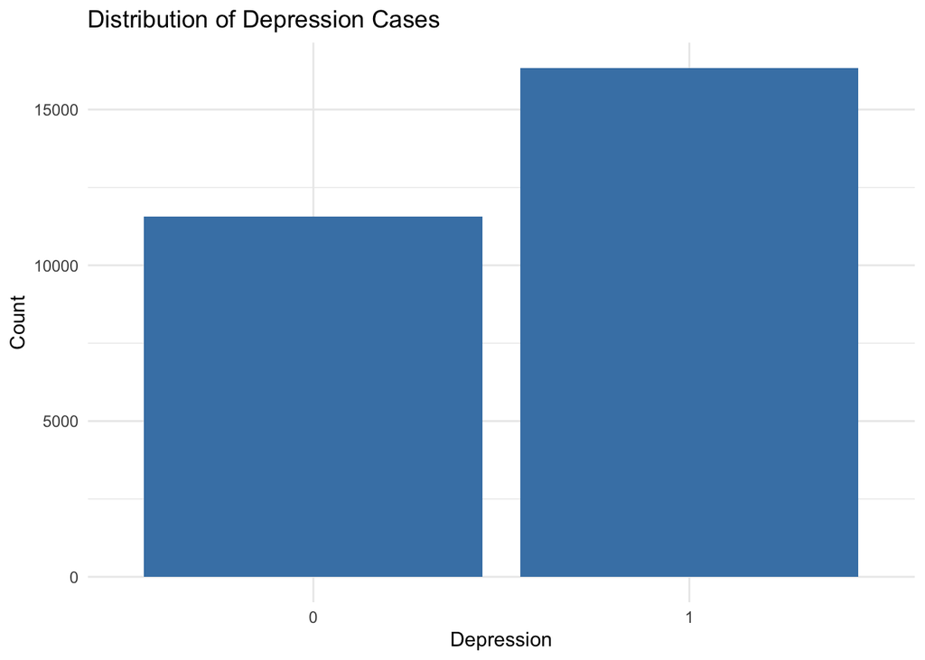

```r
library(ggplot2)

ggplot(student_depression_dataset, aes(x = Depression)) +
  geom_bar(fill = "steelblue") +
  labs(title = "Distribution of Depression Cases", x = "Depression", y = "Count") +
  theme_minimal()
```

Depression Distribution by Gender

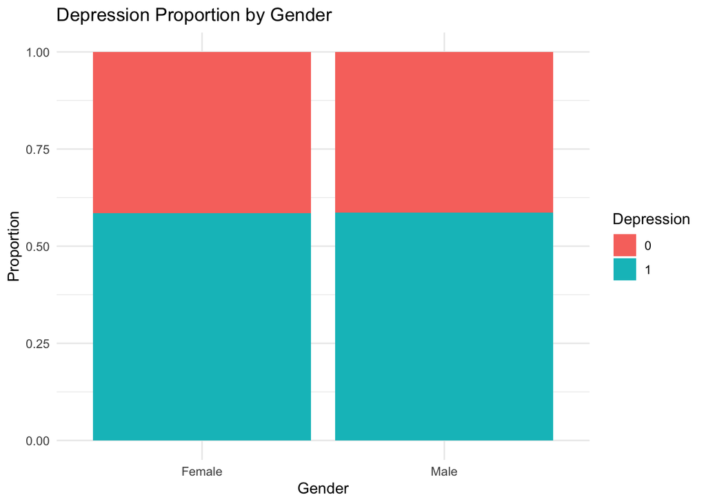

```r
ggplot(student_depression_dataset, aes(x = Gender, fill = Depression)) +
  geom_bar(position = "fill") +
  labs(title = "Depression Proportion by Gender", y = "Proportion") +
  theme_minimal()
```

Distribution of Numerical Features

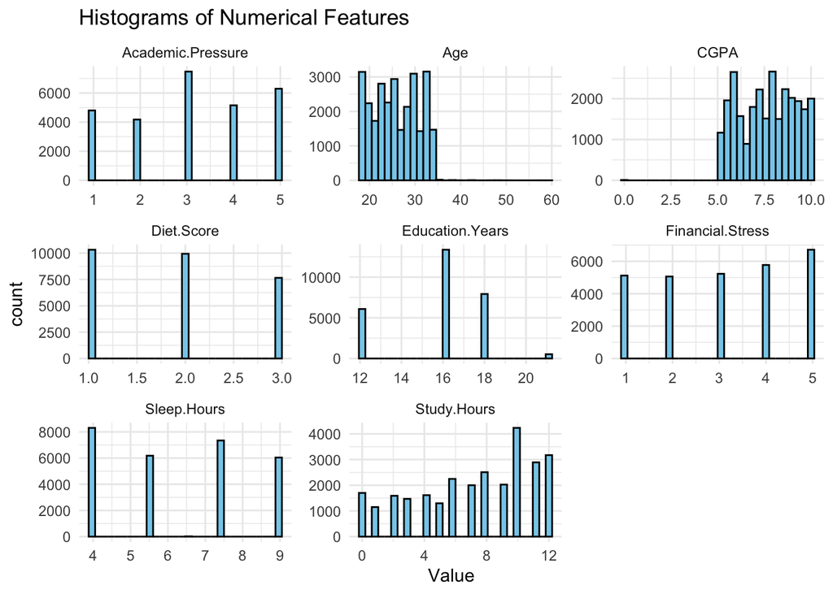

```r
num_vars <- c("Age", "CGPA", "Sleep.Hours", "Study.Hours", "Academic.Pressure",
              "Financial.Stress", "Diet.Score", "Education.Years")

library(tidyr)
library(dplyr)

student_depression_dataset %>%
  select(all_of(num_vars)) %>%
  pivot_longer(cols = everything(), names_to = "Variable", values_to = "Value") %>%
  ggplot(aes(x = Value)) +
  geom_histogram(bins = 30, fill = "skyblue", color = "black") +
  facet_wrap(~ Variable, scales = "free", ncol = 3) +
  labs(title = "Histograms of Numerical Features") +
  theme_minimal()
```

Depression Rate by Sleep Group (Barplot)

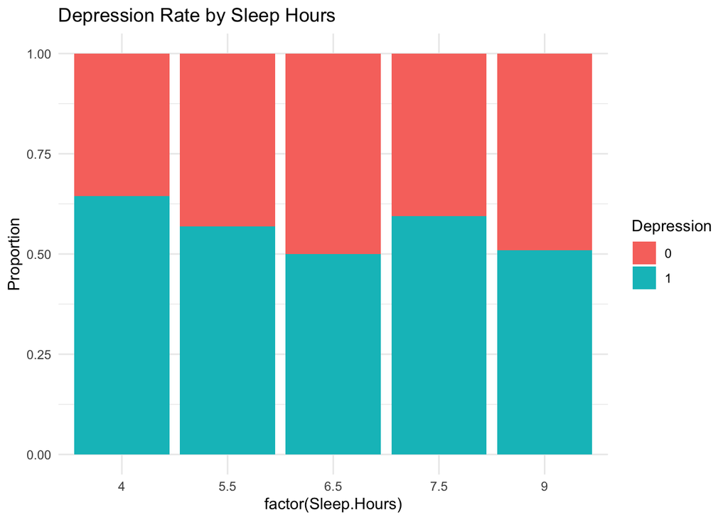

```r
library(dplyr)

student_depression_dataset %>%
  group_by(Sleep.Hours, Depression) %>%
  summarise(count = n()) %>%
  mutate(prop = count / sum(count)) %>%
  ggplot(aes(x = factor(Sleep.Hours), y = prop, fill = Depression)) +
  geom_bar(stat = "identity", position = "fill") +
  labs(title = "Depression Rate by Sleep Hours", y = "Proportion") +
  theme_minimal()
```

Boxplots of Numerical Features vs Depression

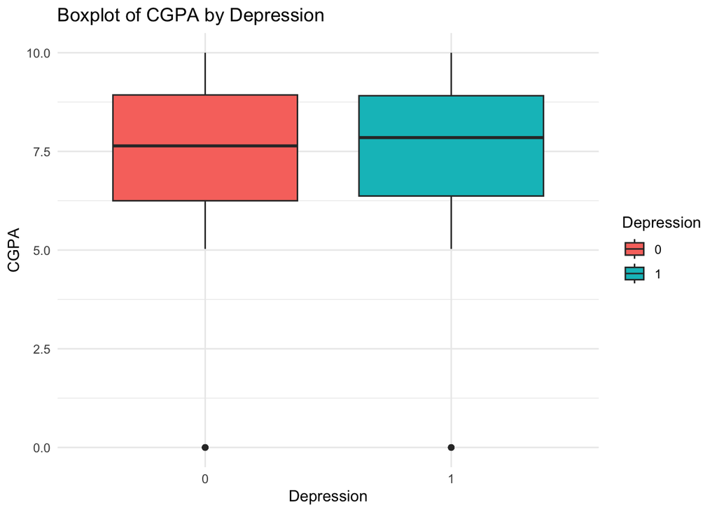

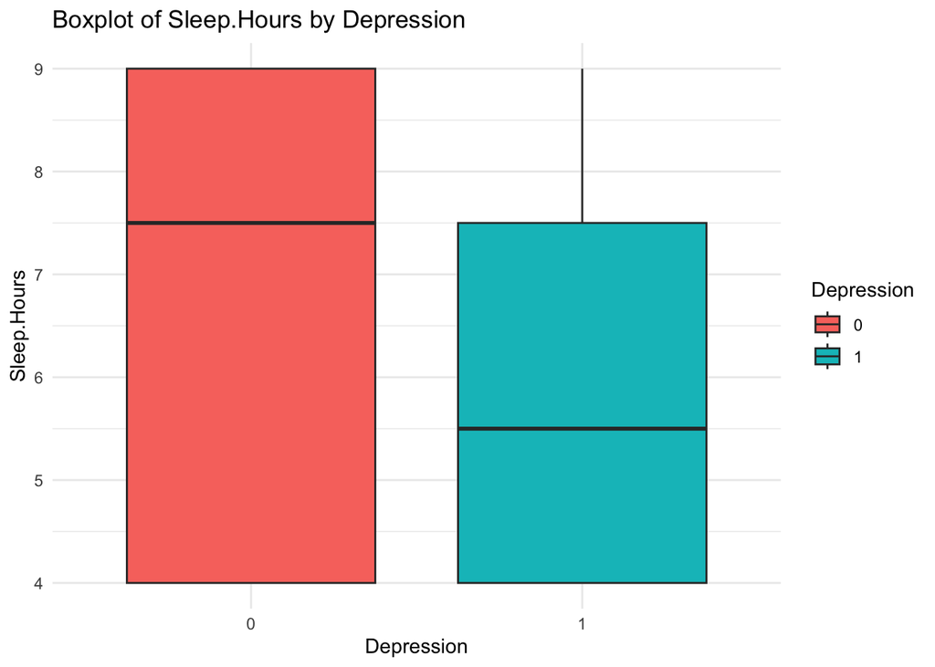

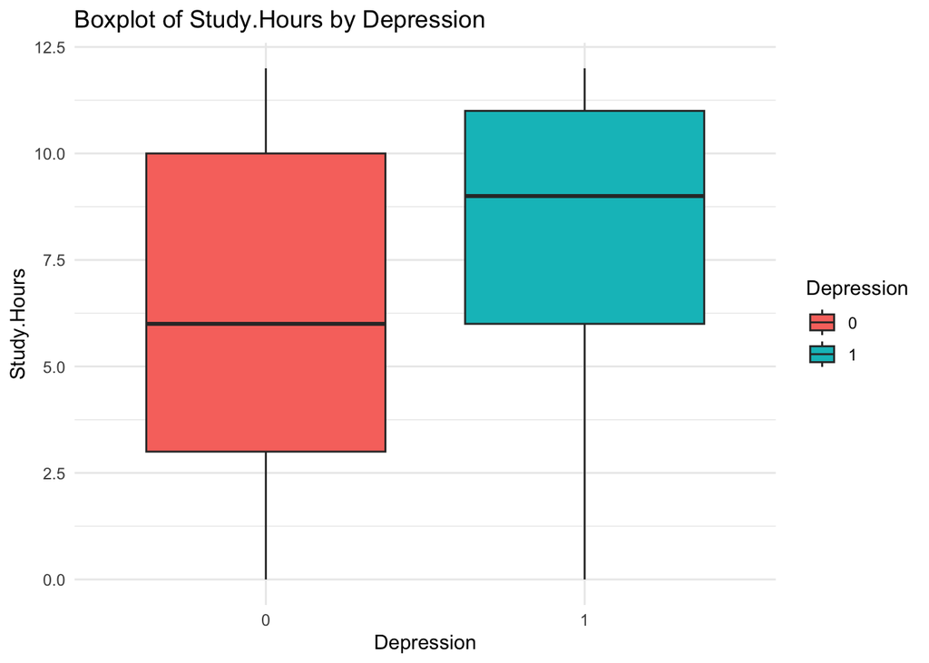

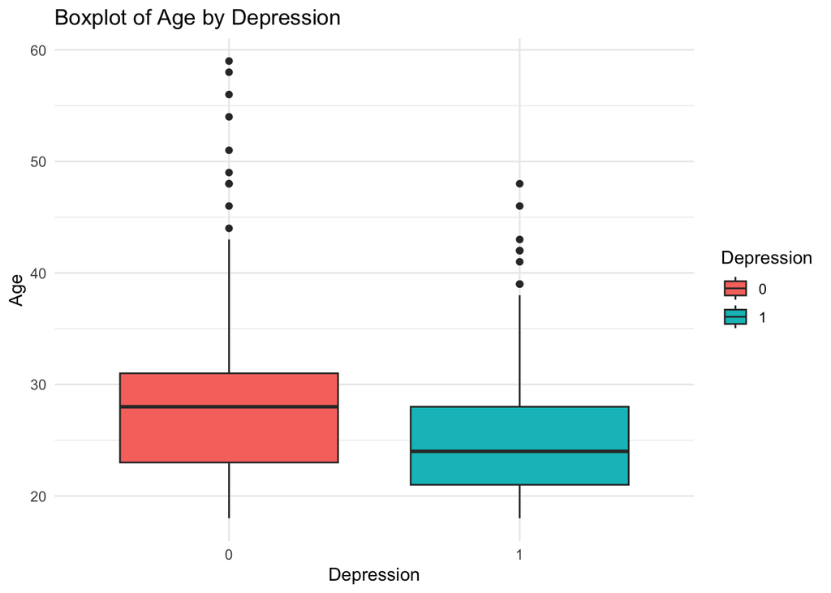

```r
# Boxplot function for multiple features
vars <- c("CGPA", "Sleep.Hours", "Study.Hours", "Age")

for (v in vars) {
  print(
    ggplot(student_depression_dataset, aes_string(x = "Depression", y = v, fill = "Depression")) +
      geom_boxplot() +
      labs(title = paste("Boxplot of", v, "by Depression")) +
      theme_minimal()
  )
}
```

Stacked Bar Plots: Categorical Scores vs Depression

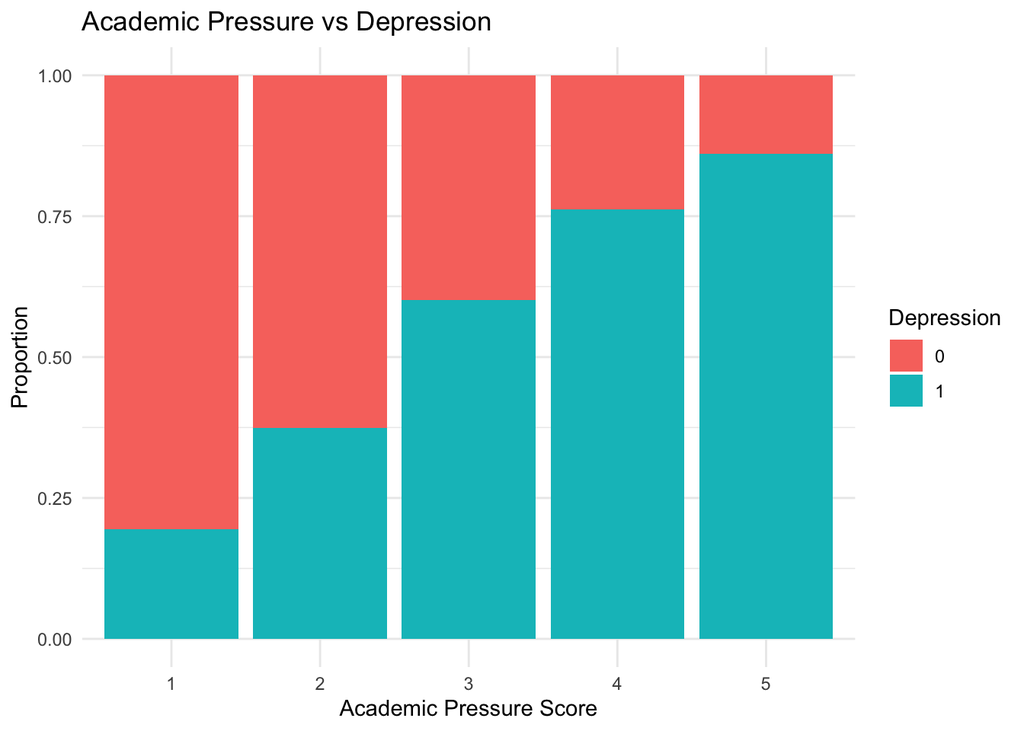

```r
# Academic Pressure vs Depression
ggplot(student_depression_dataset, aes(x = factor(Academic.Pressure), fill = Depression)) +
  geom_bar(position = "fill") +
  labs(title = "Academic Pressure vs Depression", x = "Academic Pressure Score", y = "Proportion") +
  theme_minimal()
```

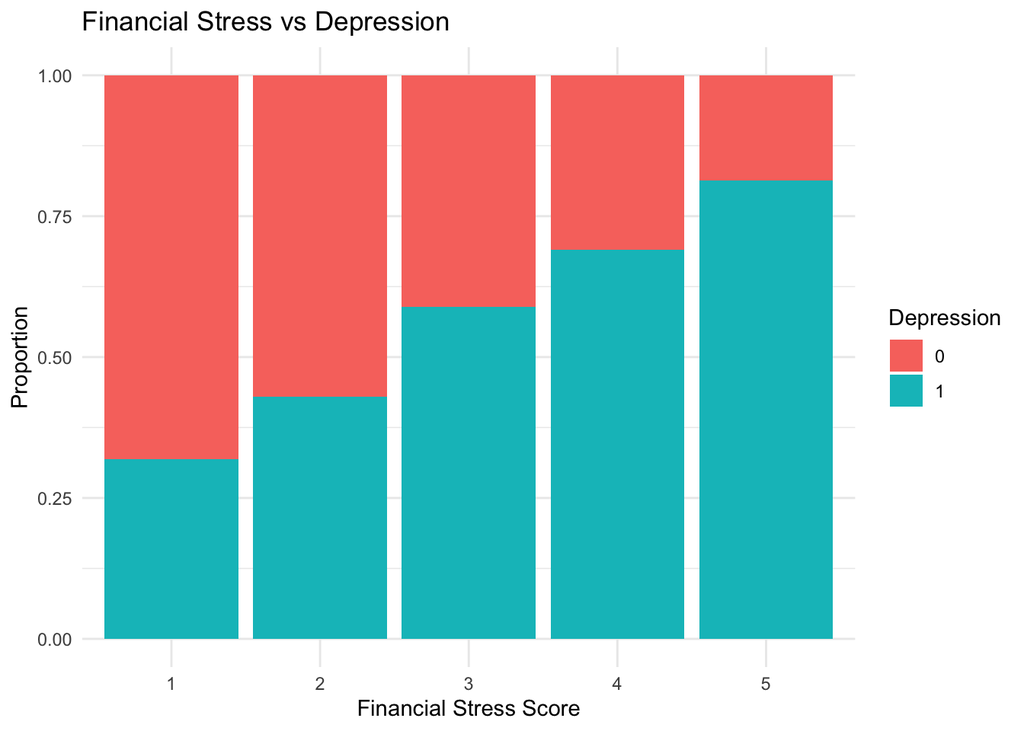

```r
# Financial Stress vs Depression
ggplot(student_depression_dataset, aes(x = factor(Financial.Stress), fill = Depression)) +
  geom_bar(position = "fill") +
  labs(title = "Financial Stress vs Depression", x = "Financial Stress Score", y = "Proportion") +
  theme_minimal()
```

Correlation Heatmap

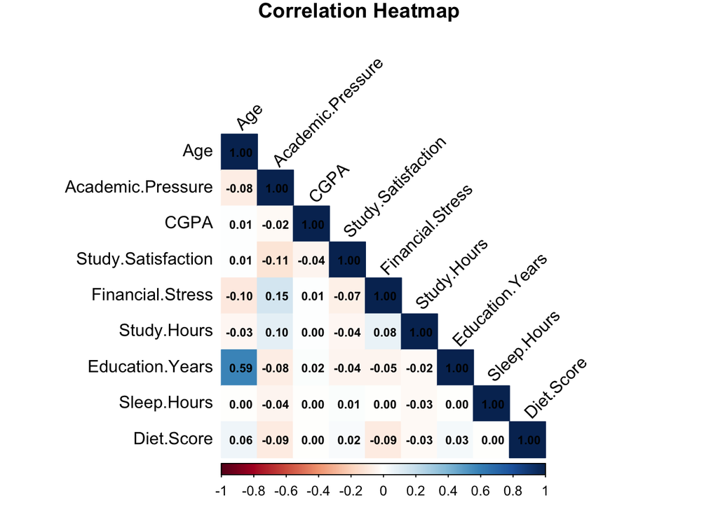

```r
library(corrplot)
# Select numeric columns and compute correlation
num_data <- student_depression_dataset %>%
  dplyr::select(where(is.numeric)) %>%
  na.omit()

cor_matrix <- cor(num_data)

# Base corrplot
corrplot(cor_matrix, method = "color", type = "lower",
         tl.col = "black", tl.srt = 45,
         addCoef.col = "black", number.cex = 0.7,
         title = "Correlation Heatmap", mar = c(0,0,1,0))
```

*Inferential Statistics*

```r
# Chi-square test: Depression vs Suicidal Thoughts
chisq.test(table(student_depression_dataset$Depression,
                 student_depression_dataset$Have.you.ever.had.suicidal.thoughts..))
```

```
##
##  Pearson's Chi-squared test with Yates' continuity correction
##
## data:  table(student_depression_dataset$Depression, student_depression_dataset$Have.you.ever.had.suicidal.thoughts..)
## X-squared = 8323.9, df = 1, p-value < 2.2e-16
```

```r
# t-test: Depression vs CGPA
t.test(CGPA ~ Depression, data = student_depression_dataset)
```

```
##
##  Welch Two Sample t-test
##
## data:  CGPA by Depression
## t = -3.6946, df = 24506, p-value = 0.0002207
## alternative hypothesis: true difference in means between group 0 and group 1 is not equal to 0
## 95 percent confidence interval:
##  -0.10148191 -0.03112933
## sample estimates:
## mean in group 0 mean in group 1
##        7.617282        7.683588
```

```r
# t-test: Depression vs Sleep Hours
t.test(Sleep.Hours ~ Depression, data = student_depression_dataset)
```

```
##
##  Welch Two Sample t-test
##
## data:  Sleep.Hours by Depression
## t = 14.089, df = 24773, p-value < 2.2e-16
## alternative hypothesis: true difference in means between group 0 and group 1 is not equal to 0
## 95 percent confidence interval:
##  0.2819361 0.3730599
## sample estimates:
## mean in group 0 mean in group 1
##        6.530393        6.202895
```

```r
# t-test: Depression vs Study Hours
t.test(Study.Hours ~ Depression, data = student_depression_dataset)
```

```
##
##  Welch Two Sample t-test
##
## data:  Study.Hours by Depression
## t = -34.944, df = 23107, p-value < 2.2e-16
## alternative hypothesis: true difference in means between group 0 and group 1 is not equal to 0
## 95 percent confidence interval:
##  -1.657688 -1.481599
## sample estimates:
## mean in group 0 mean in group 1
##        6.237959        7.807603
```

```r
# t-test: Depression vs Diet Score
t.test(Diet.Score ~ Depression, data = student_depression_dataset)
```

```
##
##  Welch Two Sample t-test
##
## data:  Diet.Score by Depression
## t = 35.237, df = 24800, p-value < 2.2e-16
## alternative hypothesis: true difference in means between group 0 and group 1 is not equal to 0
## 95 percent confidence interval:
##  0.3156233 0.3528046
## sample estimates:
## mean in group 0 mean in group 1
##        2.100130        1.765916
```

```r
# t-test: Depression vs Age
t.test(Age ~ Depression, data = student_depression_dataset)
```

```
##
##  Welch Two Sample t-test
##
## data:  Age by Depression
## t = 38.435, df = 23967, p-value < 2.2e-16
## alternative hypothesis: true difference in means between group 0 and group 1 is not equal to 0
## 95 percent confidence interval:
##  2.139699 2.369660
## sample estimates:
## mean in group 0 mean in group 1
##        27.14241        24.88773
```

```r
# Wilcoxon test: Depression vs Academic Pressure
# Academic Pressure was converted to numeric scale (ordinal) so we will use a non-parametric test.
wilcox.test(Academic.Pressure ~ Depression, data = student_depression_dataset)
```

```
##
##  Wilcoxon rank sum test with continuity correction
##
## data:  Academic.Pressure by Depression
## W = 43360836, p-value < 2.2e-16
## alternative hypothesis: true location shift is not equal to 0
```

```r
# 8. Wilcoxon test: Depression vs Financial Stress
wilcox.test(Financial.Stress ~ Depression, data = student_depression_dataset)
```

```
##
##  Wilcoxon rank sum test with continuity correction
##
## data:  Financial.Stress by Depression
## W = 55142085, p-value < 2.2e-16
## alternative hypothesis: true location shift is not equal to 0
```

```r
# 9. Wilcoxon test: Depression vs Study Satisfaction
wilcox.test(Study.Satisfaction ~ Depression, data = student_depression_dataset)
```

```
##
##  Wilcoxon rank sum test with continuity correction
##
## data:  Study.Satisfaction by Depression
## W = 112688853, p-value < 2.2e-16
## alternative hypothesis: true location shift is not equal to 0
```

```r
# 10. Logistic regression: Predicting Depression
# Combine all predictors that were either continuous or converted to ordinal scale.
log_model <- glm(Depression ~ Sleep.Hours + Study.Hours + CGPA + Age + Diet.Score +
                   Academic.Pressure + Financial.Stress + Study.Satisfaction +
                   Have.you.ever.had.suicidal.thoughts.. + Family.History.of.Mental.Illness,
                 data = student_depression_dataset, family = "binomial")
summary(log_model)
```

```
##
## Call:
## glm(formula = Depression ~ Sleep.Hours + Study.Hours + CGPA +
##     Age + Diet.Score + Academic.Pressure + Financial.Stress +
##     Study.Satisfaction + Have.you.ever.had.suicidal.thoughts.. +
##     Family.History.of.Mental.Illness, family = "binomial", data = student_depression_dataset)
##
## Coefficients:
##                                           Estimate Std. Error z value Pr(>|z|)
## (Intercept)                              -1.552925   0.179326  -8.660  < 2e-16
## Sleep.Hours                              -0.106832   0.009543 -11.194  < 2e-16
## Study.Hours                               0.117245   0.004957  23.651  < 2e-16
## CGPA                                      0.063264   0.012355   5.121 3.04e-07
## Age                                      -0.109410   0.003818 -28.654  < 2e-16
## Diet.Score                               -0.545742   0.022990 -23.738  < 2e-16
## Academic.Pressure                         0.838749   0.014821  56.594  < 2e-16
## Financial.Stress                          0.554552   0.013309  41.667  < 2e-16
## Study.Satisfaction                       -0.242970   0.013516 -17.976  < 2e-16
## Have.you.ever.had.suicidal.thoughts..Yes  2.507818   0.038971  64.352  < 2e-16
## Family.History.of.Mental.IllnessYes       0.246032   0.036337   6.771 1.28e-11
##
## (Intercept)                              ***
## Sleep.Hours                              ***
## Study.Hours                              ***
## CGPA                                     ***
## Age                                      ***
## Diet.Score                               ***
## Academic.Pressure                        ***
## Financial.Stress                         ***
## Study.Satisfaction                       ***
## Have.you.ever.had.suicidal.thoughts..Yes ***
## Family.History.of.Mental.IllnessYes      ***
## ---
## Signif. codes:  0 '***' 0.001 '**' 0.01 '*' 0.05 '.' 0.1 ' ' 1
##
## (Dispersion parameter for binomial family taken to be 1)
##
##     Null deviance: 37859  on 27900  degrees of freedom
## Residual deviance: 19521  on 27890  degrees of freedom
## AIC: 19543
##
## Number of Fisher Scoring iterations: 6
```

```r
# Optional: Convert coefficients to odds ratios
exp(coef(log_model))
```

```
##                              (Intercept)
##                                0.2116280
##                              Sleep.Hours
##                                0.8986765
##                              Study.Hours
##                                1.1243944
##                                     CGPA
##                                1.0653078
##                                      Age
##                                0.8963626
##                               Diet.Score
##                                0.5794118
##                        Academic.Pressure
##                                2.3134708
##                         Financial.Stress
##                                1.7411613
##                       Study.Satisfaction
##                                0.7842954
## Have.you.ever.had.suicidal.thoughts..Yes
##                               12.2781160
##      Family.History.of.Mental.IllnessYes
##                                1.2789408
```

The results show strong statistical evidence that several variables are significantly associated with depression among students. The chi-squared test between depression and suicidal thoughts yields a very high test statistic and a p-value less than 2.2e-16, indicating a strong relationship between the two. The t-tests show that students with depression tend to have slightly higher CGPA on average, get less sleep, study more hours per day, have lower diet scores (indicating worse eating habits), and are generally younger than those without depression. Each of these differences is statistically significant, with p-values well below 0.001. The Wilcoxon tests reveal that students with depression report higher levels of academic pressure and financial stress, and lower study satisfaction, suggesting that these ordinal stress-related factors differ significantly by depression status. Finally, the logistic regression model confirms and quantifies these relationships: all predictors included are statistically significant. For instance, having suicidal thoughts is the strongest predictor, increasing the odds of being depressed by over 12 times. Other notable effects include increased odds of depression with higher academic pressure and financial stress, while more sleep, higher diet score, age, and study satisfaction reduce the odds. Overall, the findings suggest that both lifestyle and psychological stressors meaningfully contribute to the likelihood of experiencing depression.

**Modeling with Interaction Terms**

```r
car::vif(log_model)
```

```
##                           Sleep.Hours                           Study.Hours
##                              1.006883                              1.014685
##                                  CGPA                                   Age
##                              1.005424                              1.030950
##                            Diet.Score                     Academic.Pressure
##                              1.015244                              1.084178
##                      Financial.Stress                    Study.Satisfaction
##                              1.042821                              1.012268
## Have.you.ever.had.suicidal.thoughts..      Family.History.of.Mental.Illness
##                              1.084252                              1.001697
```

```r
#VIFs show no multicollinearity issues, VIF values are well below the common threshold of 5.
cat("Logistic Regression model AIC - ", AIC(log_model))
```

```
## Logistic Regression model AIC -  19543.3
```

```r
log_model_interaction <- glm(
  Depression ~ . + Academic.Pressure:Financial.Stress,
  data = student_depression_dataset,
  family = "binomial"
)
summary(log_model_interaction)
```

```
##
## Call:
## glm(formula = Depression ~ . + Academic.Pressure:Financial.Stress,
##     family = "binomial", data = student_depression_dataset)
##
## Coefficients:
##                                           Estimate Std. Error z value Pr(>|z|)
## (Intercept)                              -1.848166   0.224640  -8.227  < 2e-16
## GenderMale                               -0.005902   0.036643  -0.161   0.8720
## Age                                      -0.115766   0.004636 -24.969  < 2e-16
## Academic.Pressure                         0.863565   0.034476  25.048  < 2e-16
## CGPA                                      0.063170   0.012366   5.108 3.25e-07
## Study.Satisfaction                       -0.241204   0.013539 -17.815  < 2e-16
## Have.you.ever.had.suicidal.thoughts..Yes  2.506755   0.038963  64.336  < 2e-16
## Financial.Stress                          0.577091   0.033861  17.043  < 2e-16
## Family.History.of.Mental.IllnessYes       0.245922   0.036352   6.765 1.33e-11
## Study.Hours                               0.117190   0.004960  23.629  < 2e-16
## Education.Years                           0.024312   0.010063   2.416   0.0157
## Sleep.Hours                              -0.106953   0.009545 -11.205  < 2e-16
## Diet.Score                               -0.545975   0.023061 -23.675  < 2e-16
## Academic.Pressure:Financial.Stress       -0.007547   0.010388  -0.727   0.4675
##
## (Intercept)                              ***
## GenderMale
## Age                                      ***
## Academic.Pressure                        ***
## CGPA                                     ***
## Study.Satisfaction                       ***
## Have.you.ever.had.suicidal.thoughts..Yes ***
## Financial.Stress                         ***
## Family.History.of.Mental.IllnessYes      ***
## Study.Hours                              ***
## Education.Years                          *
## Sleep.Hours                              ***
## Diet.Score                               ***
## Academic.Pressure:Financial.Stress
## ---
## Signif. codes:  0 '***' 0.001 '**' 0.01 '*' 0.05 '.' 0.1 ' ' 1
##
## (Dispersion parameter for binomial family taken to be 1)
##
##     Null deviance: 37859  on 27900  degrees of freedom
## Residual deviance: 19515  on 27887  degrees of freedom
## AIC: 19543
##
## Number of Fisher Scoring iterations: 6
```

```r
cat("AIC of Logistic Regression model with interaction Academic.Pressure * Financial.Stress  - ", AIC(log_model_interaction))
```

```
## AIC of Logistic Regression model with interaction Academic.Pressure * Financial.Stress  -  19542.88
```

```r
log_model_interaction2 <- glm(
  Depression ~ . + Sleep.Hours:Study.Hours,
  data = student_depression_dataset,
  family = "binomial"
)
summary(log_model_interaction2)
```

```
##
## Call:
## glm(formula = Depression ~ . + Sleep.Hours:Study.Hours, family = "binomial",
##     data = student_depression_dataset)
##
## Coefficients:
##                                           Estimate Std. Error z value Pr(>|z|)
## (Intercept)                              -1.647675   0.233843  -7.046 1.84e-12
## GenderMale                               -0.005939   0.036642  -0.162   0.8712
## Age                                      -0.115719   0.004636 -24.960  < 2e-16
## Academic.Pressure                         0.841038   0.014867  56.569  < 2e-16
## CGPA                                      0.063172   0.012366   5.109 3.25e-07
## Study.Satisfaction                       -0.241145   0.013539 -17.811  < 2e-16
## Have.you.ever.had.suicidal.thoughts..Yes  2.507044   0.038974  64.326  < 2e-16
## Financial.Stress                          0.554565   0.013312  41.658  < 2e-16
## Family.History.of.Mental.IllnessYes       0.246373   0.036353   6.777 1.23e-11
## Study.Hours                               0.097997   0.017226   5.689 1.28e-08
## Education.Years                           0.024260   0.010064   2.410   0.0159
## Sleep.Hours                              -0.127788   0.020331  -6.285 3.27e-10
## Diet.Score                               -0.545932   0.023061 -23.674  < 2e-16
## Study.Hours:Sleep.Hours                   0.003017   0.002594   1.163   0.2448
##
## (Intercept)                              ***
## GenderMale
## Age                                      ***
## Academic.Pressure                        ***
## CGPA                                     ***
## Study.Satisfaction                       ***
## Have.you.ever.had.suicidal.thoughts..Yes ***
## Financial.Stress                         ***
## Family.History.of.Mental.IllnessYes      ***
## Study.Hours                              ***
## Education.Years                          *
## Sleep.Hours                              ***
## Diet.Score                               ***
## Study.Hours:Sleep.Hours
## ---
## Signif. codes:  0 '***' 0.001 '**' 0.01 '*' 0.05 '.' 0.1 ' ' 1
##
## (Dispersion parameter for binomial family taken to be 1)
##
##     Null deviance: 37859  on 27900  degrees of freedom
## Residual deviance: 19514  on 27887  degrees of freedom
## AIC: 19542
##
## Number of Fisher Scoring iterations: 6
```

```r
cat("AIC of Logistic Regression model with interaction Sleep.Hours × Study.Hours  - ", AIC(log_model_interaction2))
```

```
## AIC of Logistic Regression model with interaction Sleep.Hours × Study.Hours  -  19542.06
```

```r
log_model_interaction3 <- glm(
  Depression ~ . + Diet.Score:Financial.Stress,
  data = student_depression_dataset,
  family = "binomial"
)
summary(log_model_interaction3)
```

```
##
## Call:
## glm(formula = Depression ~ . + Diet.Score:Financial.Stress, family = "binomial",
##     data = student_depression_dataset)
##
## Coefficients:
##                                           Estimate Std. Error z value Pr(>|z|)
## (Intercept)                              -1.986267   0.226050  -8.787  < 2e-16
## GenderMale                               -0.006224   0.036641  -0.170   0.8651
## Age                                      -0.115892   0.004637 -24.993  < 2e-16
## Academic.Pressure                         0.841214   0.014870  56.570  < 2e-16
## CGPA                                      0.063050   0.012365   5.099 3.41e-07
## Study.Satisfaction                       -0.241212   0.013541 -17.814  < 2e-16
## Have.you.ever.had.suicidal.thoughts..Yes  2.506998   0.038986  64.305  < 2e-16
## Financial.Stress                          0.622254   0.034582  17.994  < 2e-16
## Family.History.of.Mental.IllnessYes       0.246494   0.036352   6.781 1.20e-11
## Study.Hours                               0.117234   0.004960  23.635  < 2e-16
## Education.Years                           0.024680   0.010064   2.452   0.0142
## Sleep.Hours                              -0.106922   0.009545 -11.202  < 2e-16
## Diet.Score                               -0.440453   0.054608  -8.066 7.28e-16
## Financial.Stress:Diet.Score              -0.034873   0.016379  -2.129   0.0332
##
## (Intercept)                              ***
## GenderMale
## Age                                      ***
## Academic.Pressure                        ***
## CGPA                                     ***
## Study.Satisfaction                       ***
## Have.you.ever.had.suicidal.thoughts..Yes ***
## Financial.Stress                         ***
## Family.History.of.Mental.IllnessYes      ***
## Study.Hours                              ***
## Education.Years                          *
## Sleep.Hours                              ***
## Diet.Score                               ***
## Financial.Stress:Diet.Score              *
## ---
## Signif. codes:  0 '***' 0.001 '**' 0.01 '*' 0.05 '.' 0.1 ' ' 1
##
## (Dispersion parameter for binomial family taken to be 1)
##
##     Null deviance: 37859  on 27900  degrees of freedom
## Residual deviance: 19511  on 27887  degrees of freedom
## AIC: 19539
##
## Number of Fisher Scoring iterations: 6
```

```r
cat("AIC of Logistic Regression model with interaction Diet.Score × Financial.Stress - ", AIC(log_model_interaction3))
```

```
## AIC of Logistic Regression model with interaction Diet.Score × Financial.Stress -  19538.88
```

```r
log_model_interaction4 <- glm(
  Depression ~ . + Family.History.of.Mental.Illness:Have.you.ever.had.suicidal.thoughts..,
  data = student_depression_dataset,
  family = "binomial"
)
summary(log_model_interaction4)
```

```
##
## Call:
## glm(formula = Depression ~ . + Family.History.of.Mental.Illness:Have.you.ever.had.suicidal.thoughts..,
##     family = "binomial", data = student_depression_dataset)
##
## Coefficients:
##                                                                               Estimate
## (Intercept)                                                                  -1.788751
## GenderMale                                                                   -0.005949
## Age                                                                          -0.115741
## Academic.Pressure                                                             0.841080
## CGPA                                                                          0.063157
## Study.Satisfaction                                                           -0.241166
## Have.you.ever.had.suicidal.thoughts..Yes                                      2.520133
## Financial.Stress                                                              0.554487
## Family.History.of.Mental.IllnessYes                                           0.263031
## Study.Hours                                                                   0.117172
## Education.Years                                                               0.024351
## Sleep.Hours                                                                  -0.106920
## Diet.Score                                                                   -0.546075
## Have.you.ever.had.suicidal.thoughts..Yes:Family.History.of.Mental.IllnessYes -0.027670
##                                                                              Std. Error
## (Intercept)                                                                    0.205481
## GenderMale                                                                     0.036640
## Age                                                                            0.004636
## Academic.Pressure                                                              0.014868
## CGPA                                                                           0.012365
## Study.Satisfaction                                                             0.013539
## Have.you.ever.had.suicidal.thoughts..Yes                                       0.052982
## Financial.Stress                                                               0.013311
## Family.History.of.Mental.IllnessYes                                            0.059219
## Study.Hours                                                                    0.004960
## Education.Years                                                                0.010063
## Sleep.Hours                                                                    0.009544
## Diet.Score                                                                     0.023061
## Have.you.ever.had.suicidal.thoughts..Yes:Family.History.of.Mental.IllnessYes   0.074973
##                                                                              z value
## (Intercept)                                                                   -8.705
## GenderMale                                                                    -0.162
## Age                                                                          -24.965
```

[output cut: 36 more lines]

```
## Study.Hours                                                                  ***
## Education.Years                                                              *
## Sleep.Hours                                                                  ***
## Diet.Score                                                                   ***
## Have.you.ever.had.suicidal.thoughts..Yes:Family.History.of.Mental.IllnessYes
## ---
## Signif. codes:  0 '***' 0.001 '**' 0.01 '*' 0.05 '.' 0.1 ' ' 1
##
## (Dispersion parameter for binomial family taken to be 1)
##
##     Null deviance: 37859  on 27900  degrees of freedom
## Residual deviance: 19515  on 27887  degrees of freedom
## AIC: 19543
##
## Number of Fisher Scoring iterations: 6
```

```r
cat("AIC of Logistic Regression model with interaction Family.History × Suicidal.Thoughts - ", AIC(log_model_interaction4))
```

```
## AIC of Logistic Regression model with interaction Family.History × Suicidal.Thoughts -  19543.28
```

```r
combined_model <- glm(
  Depression ~ . + Diet.Score:Financial.Stress + Family.History.of.Mental.Illness:Have.you.ever.had.suicidal.thoughts..,
  data = student_depression_dataset,
  family = "binomial"
)
summary(combined_model)
```

```
##
## Call:
## glm(formula = Depression ~ . + Diet.Score:Financial.Stress +
##     Family.History.of.Mental.Illness:Have.you.ever.had.suicidal.thoughts..,
##     family = "binomial", data = student_depression_dataset)
##
## Coefficients:
##                                                                               Estimate
## (Intercept)                                                                  -1.995067
## GenderMale                                                                   -0.006283
## Age                                                                          -0.115890
## Academic.Pressure                                                             0.841290
## CGPA                                                                          0.063084
## Study.Satisfaction                                                           -0.241206
## Have.you.ever.had.suicidal.thoughts..Yes                                      2.520523
## Financial.Stress                                                              0.622293
## Family.History.of.Mental.IllnessYes                                           0.264152
## Study.Hours                                                                   0.117211
## Education.Years                                                               0.024669
## Sleep.Hours                                                                  -0.106920
## Diet.Score                                                                   -0.440434
## Financial.Stress:Diet.Score                                                  -0.034897
## Have.you.ever.had.suicidal.thoughts..Yes:Family.History.of.Mental.IllnessYes -0.028294
##                                                                              Std. Error
## (Intercept)                                                                    0.227268
## GenderMale                                                                     0.036641
## Age                                                                            0.004637
## Academic.Pressure                                                              0.014872
## CGPA                                                                           0.012365
## Study.Satisfaction                                                             0.013541
## Have.you.ever.had.suicidal.thoughts..Yes                                       0.053005
## Financial.Stress                                                               0.034582
## Family.History.of.Mental.IllnessYes                                            0.059267
## Study.Hours                                                                    0.004960
## Education.Years                                                                0.010064
## Sleep.Hours                                                                    0.009545
## Diet.Score                                                                     0.054607
## Financial.Stress:Diet.Score                                                    0.016379
## Have.you.ever.had.suicidal.thoughts..Yes:Family.History.of.Mental.IllnessYes   0.074999
##                                                                              z value
```

[output cut: 42 more lines]

```
## Education.Years                                                              *
## Sleep.Hours                                                                  ***
## Diet.Score                                                                   ***
## Financial.Stress:Diet.Score                                                  *
## Have.you.ever.had.suicidal.thoughts..Yes:Family.History.of.Mental.IllnessYes
## ---
## Signif. codes:  0 '***' 0.001 '**' 0.01 '*' 0.05 '.' 0.1 ' ' 1
##
## (Dispersion parameter for binomial family taken to be 1)
##
##     Null deviance: 37859  on 27900  degrees of freedom
## Residual deviance: 19511  on 27886  degrees of freedom
## AIC: 19541
##
## Number of Fisher Scoring iterations: 6
```

```r
cat("AIC of Logistic Regression model with combined interactions Diet.Score * Financial.Stress AIC & Family.History.of.Mental.Illness * Have.you.ever.had.suicidal.thoughts - ", AIC(combined_model))
```

```
## AIC of Logistic Regression model with combined interactions Diet.Score * Financial.Stress AIC & Family.History.of.Mental.Illness * Have.you.ever.had.suicidal.thoughts -  19540.74
```

```r
combined_model2 <- glm(
  Depression ~ . + Academic.Pressure:Financial.Stress + Family.History.of.Mental.Illness:Have.you.ever.had.suicidal.thoughts..,
  data = student_depression_dataset,
  family = "binomial"
)
summary(combined_model2)
```

```
##
## Call:
## glm(formula = Depression ~ . + Academic.Pressure:Financial.Stress +
##     Family.History.of.Mental.Illness:Have.you.ever.had.suicidal.thoughts..,
##     family = "binomial", data = student_depression_dataset)
##
## Coefficients:
##                                                                               Estimate
## (Intercept)                                                                  -1.856181
## GenderMale                                                                   -0.005959
## Age                                                                          -0.115763
## Academic.Pressure                                                             0.863544
## CGPA                                                                          0.063203
## Study.Satisfaction                                                           -0.241198
## Have.you.ever.had.suicidal.thoughts..Yes                                      2.519758
## Financial.Stress                                                              0.576989
## Family.History.of.Mental.IllnessYes                                           0.262869
## Study.Hours                                                                   0.117169
## Education.Years                                                               0.024300
## Sleep.Hours                                                                  -0.106952
## Diet.Score                                                                   -0.546023
## Academic.Pressure:Financial.Stress                                           -0.007516
## Have.you.ever.had.suicidal.thoughts..Yes:Family.History.of.Mental.IllnessYes -0.027209
##                                                                              Std. Error
## (Intercept)                                                                    0.225727
## GenderMale                                                                     0.036643
## Age                                                                            0.004636
## Academic.Pressure                                                              0.034476
## CGPA                                                                           0.012366
## Study.Satisfaction                                                             0.013540
## Have.you.ever.had.suicidal.thoughts..Yes                                       0.052966
## Financial.Stress                                                               0.033863
## Family.History.of.Mental.IllnessYes                                            0.059173
## Study.Hours                                                                    0.004960
## Education.Years                                                                0.010063
## Sleep.Hours                                                                    0.009545
## Diet.Score                                                                     0.023062
## Academic.Pressure:Financial.Stress                                             0.010388
## Have.you.ever.had.suicidal.thoughts..Yes:Family.History.of.Mental.IllnessYes   0.074957
##                                                                              z value
```

[output cut: 42 more lines]

```
## Education.Years                                                              *
## Sleep.Hours                                                                  ***
## Diet.Score                                                                   ***
## Academic.Pressure:Financial.Stress
## Have.you.ever.had.suicidal.thoughts..Yes:Family.History.of.Mental.IllnessYes
## ---
## Signif. codes:  0 '***' 0.001 '**' 0.01 '*' 0.05 '.' 0.1 ' ' 1
##
## (Dispersion parameter for binomial family taken to be 1)
##
##     Null deviance: 37859  on 27900  degrees of freedom
## Residual deviance: 19515  on 27886  degrees of freedom
## AIC: 19545
##
## Number of Fisher Scoring iterations: 6
```

```r
cat("AIC of Logistic Regression model with combined interactions Academic.Pressure*Financial.Stress + Family.History.of.Mental.Illness*Have.you.ever.had.suicidal.thoughts - ", AIC(combined_model2) )
```

```
## AIC of Logistic Regression model with combined interactions Academic.Pressure*Financial.Stress + Family.History.of.Mental.Illness*Have.you.ever.had.suicidal.thoughts -  19544.75
```

```r
combined_model3 <- glm(
  Depression ~ . + Academic.Pressure:Financial.Stress + Diet.Score:Financial.Stress,
  data = student_depression_dataset,
  family = "binomial"
)
summary(combined_model3)
```

```
##
## Call:
## glm(formula = Depression ~ . + Academic.Pressure:Financial.Stress +
##     Diet.Score:Financial.Stress, family = "binomial", data = student_depression_dataset)
##
## Coefficients:
##                                           Estimate Std. Error z value Pr(>|z|)
## (Intercept)                              -2.038529   0.242640  -8.401  < 2e-16
## GenderMale                               -0.006222   0.036643  -0.170   0.8652
## Age                                      -0.115908   0.004637 -24.996  < 2e-16
## Academic.Pressure                         0.859694   0.034487  24.928  < 2e-16
## CGPA                                      0.063090   0.012366   5.102 3.36e-07
## Study.Satisfaction                       -0.241240   0.013541 -17.815  < 2e-16
## Have.you.ever.had.suicidal.thoughts..Yes  2.506886   0.038979  64.314  < 2e-16
## Financial.Stress                          0.639627   0.045293  14.122  < 2e-16
## Family.History.of.Mental.IllnessYes       0.246594   0.036355   6.783 1.18e-11
## Study.Hours                               0.117230   0.004960  23.633  < 2e-16
## Education.Years                           0.024632   0.010064   2.448   0.0144
## Sleep.Hours                              -0.106948   0.009545 -11.204  < 2e-16
## Diet.Score                               -0.442120   0.054741  -8.077 6.66e-16
## Academic.Pressure:Financial.Stress       -0.006194   0.010413  -0.595   0.5520
## Financial.Stress:Diet.Score              -0.034269   0.016413  -2.088   0.0368
##
## (Intercept)                              ***
## GenderMale
## Age                                      ***
## Academic.Pressure                        ***
## CGPA                                     ***
## Study.Satisfaction                       ***
## Have.you.ever.had.suicidal.thoughts..Yes ***
## Financial.Stress                         ***
## Family.History.of.Mental.IllnessYes      ***
## Study.Hours                              ***
## Education.Years                          *
## Sleep.Hours                              ***
## Diet.Score                               ***
## Academic.Pressure:Financial.Stress
## Financial.Stress:Diet.Score              *
## ---
## Signif. codes:  0 '***' 0.001 '**' 0.01 '*' 0.05 '.' 0.1 ' ' 1
##
## (Dispersion parameter for binomial family taken to be 1)
##
##     Null deviance: 37859  on 27900  degrees of freedom
## Residual deviance: 19511  on 27886  degrees of freedom
## AIC: 19541
##
## Number of Fisher Scoring iterations: 6
```

```r
cat("AIC of Logistic Regression model with combined interactions Academic.Pressure*Financial.Stress + Diet.Score*Financial.Stress - ", AIC(combined_model3) )
```

```
## AIC of Logistic Regression model with combined interactions Academic.Pressure*Financial.Stress + Diet.Score*Financial.Stress -  19540.52
```

After evaluating multiple logistic regression models with interaction terms, the model incorporating the interaction between Diet.Score and Financial.Stress (AIC = 19539) stands out as the best choice. This model demonstrates superior performance in terms of statistical fit and practical relevance compared to alternatives. The base model without any interactions has an AIC of 19543, while the Diet.Score × Financial.Stress interaction model reduces this to 19539 which is a meaningful improvement as ΔAIC reduces by -4. In contrast, other interactions either fail to lower the AIC (e.g., Academic.Pressure × Financial.Stress retains AIC = 19543) or offer only marginal gains (e.g., Sleep.Hours × Study.Hours reduces AIC by just 1). The combined models (e.g., Diet.Score × Financial.Stress + Family.History × Suicidal.Thoughts) yield no additional benefit as its AIC is 19541, confirming that simplicity is preferable. The Diet.Score × Financial.Stress interaction is statistically significant having p equal to 0.033, indicating it meaningfully contributes to predicting depression. This aligns with established research linking financial stress and poor diet to mental health deterioration. Also,When we combine multiple interactions like Diet.Score × Financial.Stress + Family.History × Suicidal.Thoughts . It introduces unnecessary complexity without improving fit as its AIC is 19541 which is greater than 19539 AIC for Diet.Score × Financial.Stress interaction.